# Challenge 4

Author

Michelle Kairy

#### Set-Up

```r
library(tidyverse)
library(here)
```

#### Data

```r
avocado <- read_csv(here::here("supporting_artifacts", "supporting_data", "avocado.csv"))
```

#### Data Cleaning

```r
ca_city = data.frame(city = c("LosAngeles", "SanDiego", "Sacramento", "SanFrancisco"))

avocado <- avocado |>
  filter(region != "TotalUS") |>
  rename(small = `4046`, large = `4225`, xlarge = `4770`)
```

## Challenge Problem

### Set-Up

Data for this challenge comes from FRED’s All Transcations House Price Index series for San Diego, LA, San Francsico, and Sacramento.

```r
sandiego <- read_csv(here::here("supporting_artifacts", "supporting_data", "sandiego.csv"))
sac <- read_csv(here::here("supporting_artifacts", "supporting_data", "sac.csv"))
sanfran <- read_csv(here::here("supporting_artifacts", "supporting_data", "sanfran.csv"))
la <- read_csv(here::here("supporting_artifacts", "supporting_data", "la.csv"))
```

### Data Cleaning

```r
avocado_cal <- avocado |>
  semi_join(ca_city, by = c("region" = "city")) |>
  group_by(region, year) |>
  summarise(avocado_price = mean(AveragePrice),
            avocado_volume = mean(`Total Volume`)) |>
  mutate(year = as.factor(year))

house_prices <- sandiego |>
  full_join(sac, by = c("DATE" = "DATE")) |>
  full_join(la, by = c("DATE" = "DATE")) |>
  full_join(sanfran, by = c("DATE" = "DATE")) |>
  separate(DATE, c("year", "month", "day"), "-") |>
  rename(LosAngeles = ATNHPIUS06037A,
         SanDiego = ATNHPIUS06073A,
         SanFrancisco = ATNHPIUS41884Q,
         Sacramento = ATNHPIUS06067A) |>
  mutate(across(where(is.numeric), ~.*2000),
         year = as.factor(year)) |>
  pivot_longer(cols = SanDiego:SanFrancisco,
               names_to = "city",
               values_to = "price") |>
  group_by(city, year) |>
  summarise(house_price = mean(price, na.rm = TRUE))
```

### Merge Data

```r
avocado_houses <- house_prices |>
  inner_join(avocado_cal, by = c("city" = "region", "year" = "year"))
```

### Plot Data

Originally, I plotted my data using 3 different boxplot visualizations, however, it wasn’t a useful visualization to compare three different variables over the same period. In my revision, I summarised the data before plotting to create clean lines. To better compare the data, I rescaled the variables using the rescale function we used in a later lab.

To scale the variables to be plotted together, I am using the rescale function created in Lab 7.

```r
rescale_01 <- function(variable) {
    stopifnot(is.numeric(variable),
            length(variable) > 1)
  variable = (variable - min(variable , na.rm = TRUE)) /
           (max(variable, na.rm = TRUE) - min(variable, na.rm = TRUE))
  return(variable)
}
```

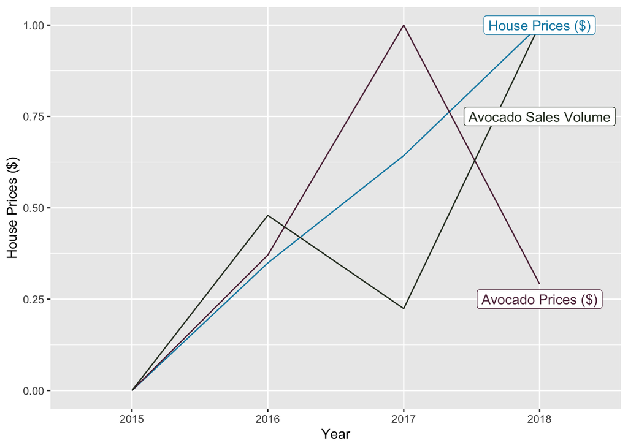

```r
avocado_houses_sum <- avocado_houses |>
  group_by(year) |>
  summarise(across(.cols = c(house_price:avocado_volume), .fns = mean)) |>
  mutate(across(.cols = c(house_price:avocado_volume), .fns = rescale_01))



ggplot(data = avocado_houses_sum) +
  geom_line(mapping = aes(x = year, y = house_price, group = 1), color = "#118AB2") +
  geom_line(mapping = aes(x = year, y = avocado_price, group = 1), color = "#5D2E46") +
  geom_line(mapping = aes(x = year, y = avocado_volume, group = 1), color = "#303A2B") +
  labs(x = "Year", y = "House Prices ($)") +
  annotate(geom = "label",
           y = 0.25,
           x = "2018",
           label = "Avocado Prices ($)",
           color = "#5D2E46") +
  annotate(geom = "label",
           y = 0.75,
           x = "2018",
           label = "Avocado Sales Volume",
           color = "#303A2B") +
  annotate(geom = "label",
           y = 1,
           x = "2018",
           label = "House Prices ($)",
           color = "#118AB2")
```